# reproducible research workshop

Noushin Nabavi & Monica Granados

### learning outcomes

- 1. explain what is reproducible research
- 2. tools that can help make research more reproducible
- 3. components of a reproducible project
- 4. use of rmarkdown for reproducible research
- 5. use of github for reproducible research

### What is reproducible research

- Reproducible research means that future you and anyone else will be able to pick up your analysis and reproduce the same results, including figures and tables.
- This implies well-documented research, well commented codes and documents and reasoning behind analyses
- Also, the communication aspect should not be an afterthought, it should be recorded with the analysis as you are going through it.

Rmarkdown is a way of literate programing that keeps code, words and sentences together. The ability to easily collaborate and share your analysis goes hand-in-hand with good record-keeping and reproducibility.

### What is reproducible research

Rmarkdown is a way of literate programing that keeps code, words and sentences together.

The ability to easily collaborate and share your analysis goes hand-in-hand with good record-keeping and reproducibility.

### Slide With Code

```r
summary(cars)
```

```
     speed           dist
 Min.   : 4.0   Min.   :  2.00
 1st Qu.:12.0   1st Qu.: 26.00
 Median :15.0   Median : 36.00
 Mean   :15.4   Mean   : 42.98
 3rd Qu.:19.0   3rd Qu.: 56.00
 Max.   :25.0   Max.   :120.00
```

### Slide With Plot

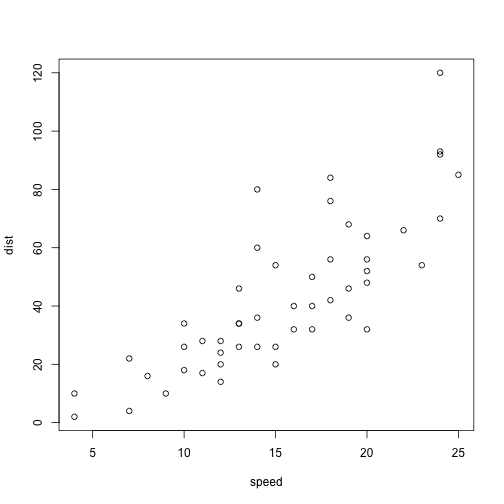